# INFO hw4

Jiaxi Geng

11/7/2021

```r
library(renv)
renv::init()
library(rprojroot)
library(here)
library(psych)
library(dplyr)
here::i_am("Rmd/report.Rmd")
```

```
## here() starts at /Users/gracegeng/Desktop/info-main
```

Import raw data set

Subset the table with non-missing value in sf, crp and agp

```r
brindanew <- brinda[!is.na(brinda$sf)&!is.na(brinda$crp)&!is.na(brinda$agp), ]
```

Imputation of zero value in crp, agp, and sf – change it to 0.01

```r
brindanew$crp[which(brindanew$crp==0)]<-0.01
brindanew$agp[which(brindanew$agp==0)]<-0.01
brindanew$sf[which(brindanew$sf==0)] <- 0.01
```

Add group category to table

```r
brindanew$category <- NA
brindanew$category[which(brindanew$crp<=5 & brindanew$agp<=1)] <- "Reference"
brindanew$category[which(brindanew$crp>5 & brindanew$agp<=1)] <- "Incubation"
brindanew$category[which(brindanew$crp>5 & brindanew$agp>1)] <- "Early convalescence"
brindanew$category[which(brindanew$crp<=5 & brindanew$agp>1)] <- "Late convalescence"
```

Method 1: CF (Ratio Adjustment)

GM (geometric mean) of ferritin in each group

```r
# reference group
sf_ref <- brindanewa$sf[which(brindanewa$category == "Reference" & brindanewa$sf >0)]
sf_ref_gm <- geometric.mean(sf_ref,na.rm=FALSE)
sf_ref_gm
```

```
## [1] 24.06414
```

```r
# incubation group
sf_inc <- brindanewa$sf[which(brindanewa$category == "Incubation" & brindanewa$sf >0)]
sf_inc_gm <- geometric.mean(sf_inc,na.rm=FALSE)
sf_inc_gm
```

```
## [1] 34.8111
```

```r
# early convalescence group
sf_early <- brindanewa$sf[which(brindanewa$category == "Early convalescence" & brindanewa$sf >0)]
sf_early_gm <- geometric.mean(sf_early,na.rm=FALSE)
sf_early_gm
```

```
## [1] 61.59249
```

```r
# late convalescence group
sf_late <- brindanewa$sf[which(brindanewa$category == "Late convalescence" & brindanewa$sf >0)]
sf_late_gm <- geometric.mean(sf_late,na.rm=FALSE)
sf_late_gm
```

```
## [1] 34.22754
```

Calculate CF value for each category

```r
brindanewa$cf_sf <- NA
brindanewa$cf_sf[which(brindanewa$category == "Reference")] <- 1
brindanewa$cf_sf[which(brindanewa$category == "Incubation")] <- sf_ref_gm/sf_inc_gm
brindanewa$cf_sf[which(brindanewa$category == "Early convalescence")] <- sf_ref_gm/sf_early_gm
brindanewa$cf_sf[which(brindanewa$category == "Late convalescence")] <- sf_ref_gm/sf_late_gm
```

Multiply the raw ferritin value by CF to get adjusted ferritin value, creating new column called sf_adj

```r
brindanewa$sf_adj1 <- brindanewa$sf * brindanewa$cf_sf
```

Method 1 finally has data set brindanewa and sf adjustment value sf_adj1.

Summary information of sf adjustment value

```r
mean_method1 <- mean(brindanewa$sf_adj1)
mean_method1
```

```
## [1] 35.24128
```

```r
mean_method1_ <- brindanewa %>% group_by(category) %>% summarise_at (vars(sf_adj1),list(name=mean))
mean_method1_
```

```
## # A tibble: 4 x 2
##   category             name
##   <chr>               <dbl>
## 1 Early convalescence  36.4
## 2 Incubation           34.1
## 3 Late convalescence   36.7
## 4 Reference            34.2
```

Add plots

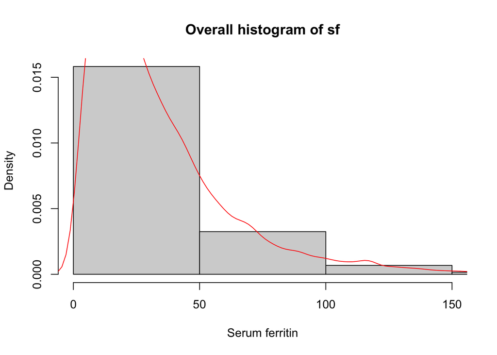

```r
# overall histogram
hist(brindanewa$sf_adj1, prob=TRUE, xlab="Serum ferritin", main="Overall histogram of sf",xlim=c(0,150))
lines(density(brindanewa$sf_adj1),col="red")
```

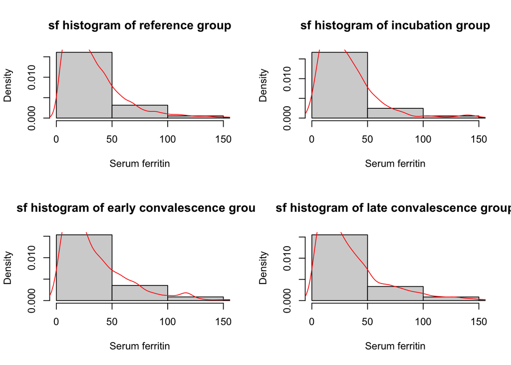

```r
# plot by group
par(mfrow=c(2,2))
hist(brindanewa$sf_adj1[which(brindanewa$category == "Reference")], prob=TRUE, xlab="Serum ferritin", main="sf histogram of reference group",xlim=c(0,150))
lines(density(brindanewa$sf_adj1[which(brindanewa$category == "Reference")]),col="red")
hist(brindanewa$sf_adj1[which(brindanewa$category == "Incubation")], prob=TRUE, xlab="Serum ferritin", main="sf histogram of incubation group",xlim=c(0,150))
lines(density(brindanewa$sf_adj1[which(brindanewa$category == "Incubation")]),col="red")
hist(brindanewa$sf_adj1[which(brindanewa$category == "Early convalescence")], prob=TRUE, xlab="Serum ferritin", main="sf histogram of early convalescence group",xlim=c(0,150))
lines(density(brindanewa$sf_adj1[which(brindanewa$category == "Early convalescence")]),col="red")
hist(brindanewa$sf_adj1[which(brindanewa$category == "Late convalescence")], prob=TRUE, xlab="Serum ferritin", main="sf histogram of late convalescence group",xlim=c(0,150))
lines(density(brindanewa$sf_adj1[which(brindanewa$category == "Late convalescence")]),col="red")
```

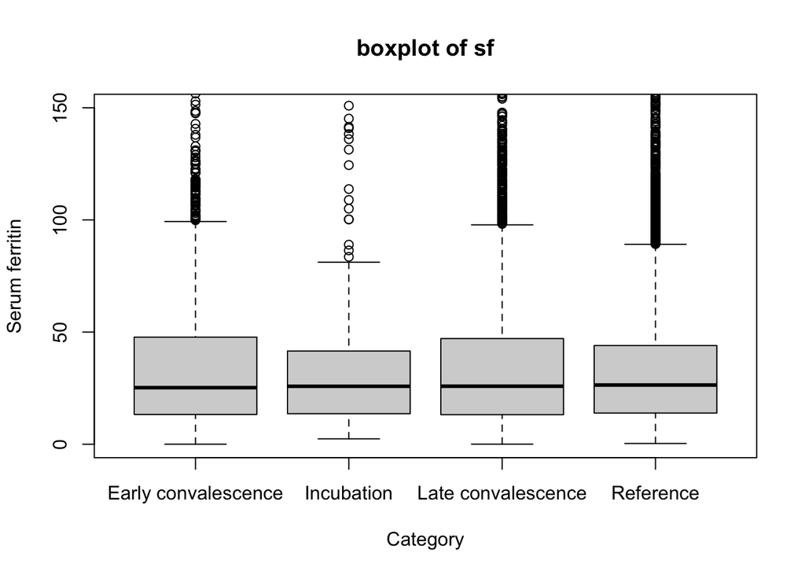

```r
# boxplot for each group
par(mfrow=c(1,1))
boxplot(brindanewa$sf_adj1~brindanewa$category,main="boxplot of sf", xlab="Category",ylab="Serum ferritin",ylim=c(0,150))
```

Method 2: RC (Regression adjusted equation)

Fit the simple linear regression model

```r
model1 <- lm(brindanew$sf_ln ~ brindanew$crp_ln + brindanew$agp_ln)
model1$coefficients
```

```
##      (Intercept) brindanew$crp_ln brindanew$agp_ln
##       3.47866545       0.09486619       0.52200806
```

Get RC equation: add reference value for crp and agp. Derive the reference value from paper: for WRA, reference value of ln(AGP) is -0.52, and the reference value of ln(CRP) is -2.26

```r
brindanewb <-
  brindanew%>%
  mutate(crp_ln = case_when (brindanew$crp_ln < (-2.26) ~ -2.26,
                              brindanew$crp_ln >= (-2.26) ~ crp_ln),
         agp_ln = case_when (brindanew$agp_ln < (-0.52) ~ -0.52,
                             brindanew$agp_ln >= (-0.52) ~ agp_ln))
```

Get the adjusted sf value for each subject

```r
brindanewb$sf_adj2_ln <- log(brindanewb$sf) - model1$coefficients[2]*(log(brindanewb$crp)+2.26) --model1$coefficients[3]*(log(brindanewb$agp)+0.52)
brindanewb$sf_adj2 <- exp(brindanewb$sf_adj2_ln)
brindanewb$sf_adj2 <- ifelse(brindanewb$category == "Reference", brindanewb$sf, brindanewb$sf_adj2)
```

Method 2 finally has data set brindanewb and sf adjustment value sf_adj2.

Summary information of sf adjustment value

```r
mean_method2 <- mean(brindanewb$sf_adj2)
mean_method2
```

```
## [1] 53.61242
```

```r
mean_method2_ <- brindanewb %>% group_by(category) %>% summarise_at (vars(sf_adj2),list(name=mean))
mean_method2_
```

```
## # A tibble: 4 x 2
##   category             name
##   <chr>               <dbl>
## 1 Early convalescence  95.4
## 2 Incubation           38.0
## 3 Late convalescence   65.8
## 4 Reference            33.9
```

Add plots

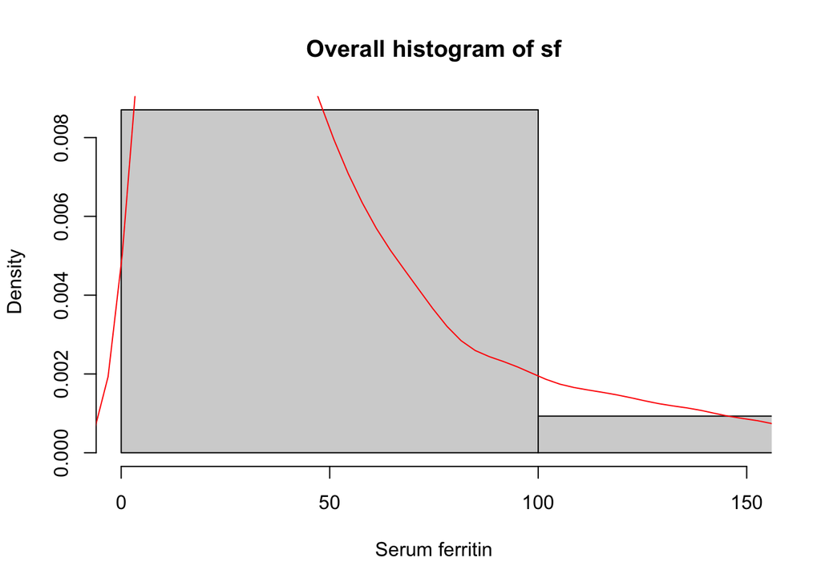

```r
# overall histogram
hist(brindanewb$sf_adj2, prob=TRUE, xlab="Serum ferritin", main="Overall histogram of sf",xlim=c(0,150))
lines(density(brindanewb$sf_adj2),col="red")
```

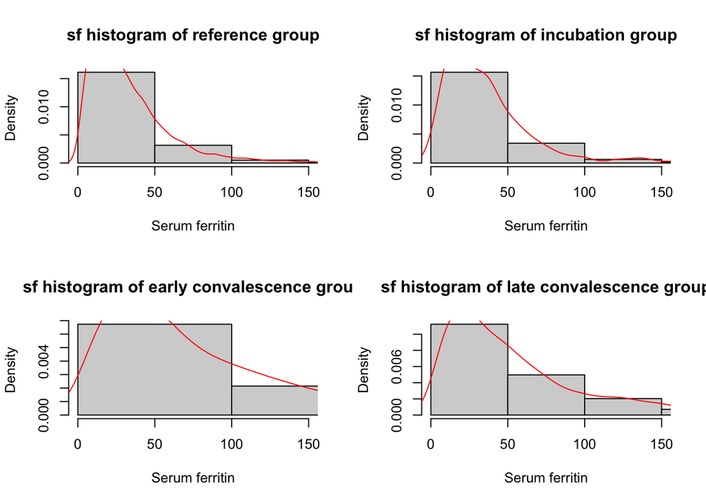

```r
# histogram by group
par(mfrow=c(2,2))
hist(brindanewb$sf_adj2[which(brindanewb$category == "Reference")], prob=TRUE, xlab="Serum ferritin", main="sf histogram of reference group",xlim=c(0,150))
lines(density(brindanewb$sf_adj2[which(brindanewb$category == "Reference")]),col="red")
hist(brindanewb$sf_adj2[which(brindanewb$category == "Incubation")], prob=TRUE, xlab="Serum ferritin", main="sf histogram of incubation group",xlim=c(0,150))
lines(density(brindanewb$sf_adj2[which(brindanewb$category == "Incubation")]),col="red")
hist(brindanewb$sf_adj2[which(brindanewb$category == "Early convalescence")], prob=TRUE, xlab="Serum ferritin", main="sf histogram of early convalescence group",xlim=c(0,150))
lines(density(brindanewb$sf_adj2[which(brindanewb$category == "Early convalescence")]),col="red")
hist(brindanewb$sf_adj2[which(brindanewb$category == "Late convalescence")], prob=TRUE, xlab="Serum ferritin", main="sf histogram of late convalescence group",xlim=c(0,150))
lines(density(brindanewb$sf_adj2[which(brindanewb$category == "Late convalescence")]),col="red")
```

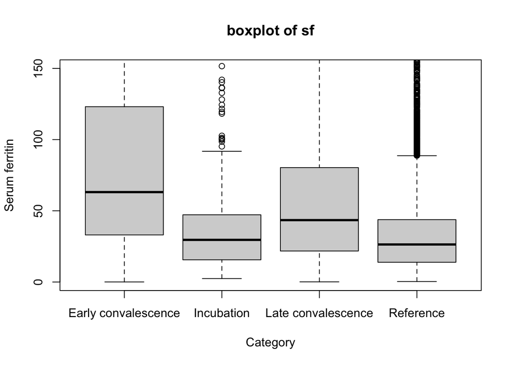

```r
# boxplot by group
par(mfrow=c(1,1))
boxplot(brindanewb$sf_adj2~brindanewb$category,main="boxplot of sf", xlab="Category",ylab="Serum ferritin",ylim=c(0,150))
```

Method 3: hybrid Incubation group

```r
brindanew_c_inc_ <- brindanew[brindanew$category == "Incubation",]
brindanew_c_inc <- brindanew_c_inc_ %>%
  mutate(
        crp_ln = case_when (brindanew_c_inc_$crp_ln < (-2.26) ~ -2.26,
                            brindanew_c_inc_$crp_ln >= (-2.26) ~ crp_ln),
        agp_ln = case_when (brindanew_c_inc_$agp_ln < (-0.52) ~ -0.52,
                            brindanew_c_inc_$agp_ln >= (-0.52) ~ agp_ln))
model2 <- lm(brindanew_c_inc$sf_ln ~ brindanew_c_inc$crp_ln + brindanew_c_inc$agp_ln)
model2$coefficients
```

```
##            (Intercept) brindanew_c_inc$crp_ln brindanew_c_inc$agp_ln
##              2.9517491              0.2716372              0.4110701
```

```r
brindanew_c_inc$sf_adj3_ln <- log(brindanew_c_inc$sf) - model2$coefficients[2]*(log(brindanew_c_inc$crp)+2.26) - model2$coefficients[3]*(log(brindanew_c_inc$agp)+0.52)
brindanew_c_inc$sf_adj3 <- exp(brindanew_c_inc$sf_adj3_ln)
```

Early convalescence group

```r
brindanew_c_early_ <- brindanew[brindanew$category == "Early convalescence",]
brindanew_c_early <- brindanew_c_early_%>%
  mutate(
        crp_ln = case_when (brindanew_c_early_$crp_ln < (-2.26) ~ -2.26,
                            brindanew_c_early_$crp_ln >= (-2.26) ~ crp_ln),
        agp_ln = case_when (brindanew_c_early_$agp_ln < (-0.52) ~ -0.52,
                            brindanew_c_early_$agp_ln >= (-0.52) ~ agp_ln))
model3 <- lm(brindanew_c_early$sf_ln ~ brindanew_c_early$crp_ln + brindanew_c_early$agp_ln)
model3$coefficients
```

```
##              (Intercept) brindanew_c_early$crp_ln brindanew_c_early$agp_ln
##                2.7583839                0.3942462                0.6078073
```

```r
# log(sf) = 2.76 + 0.39*log(crp) + 0.61*log(agp)
brindanew_c_early$sf_adj3_ln <- log(brindanew_c_early$sf) - model3$coefficients[2]*(log(brindanew_c_early$crp)+2.26) - model3$coefficients[3]*(log(brindanew_c_early$agp)+0.52)
brindanew_c_early$sf_adj3 <- exp(brindanew_c_early$sf_adj3_ln)
```

Late convalescence group

```r
brindanew_c_late_ <- brindanew[brindanew$category == "Late convalescence",]
brindanew_c_late <- brindanew_c_late_ %>%
  mutate(
        crp_ln = case_when (brindanew_c_late_$crp_ln < (-2.26) ~ -2.26,
                            brindanew_c_late_$crp_ln >= (-2.26) ~ crp_ln),
        agp_ln = case_when (brindanew_c_late_$agp_ln < (-0.52) ~ -0.52,
                            brindanew_c_late_$agp_ln >= (-0.52) ~ agp_ln))
model4 <- lm(brindanew_c_late$sf_ln ~ brindanew_c_late$crp_ln + brindanew_c_late$agp_ln)
model4$coefficients
```

```
##             (Intercept) brindanew_c_late$crp_ln brindanew_c_late$agp_ln
##              3.32599680              0.07038154              0.75046804
```

```r
brindanew_c_late$sf_adj3_ln <- log(brindanew_c_late$sf) - model4$coefficients[2]*(log(brindanew_c_late$crp)+2.26) - model4$coefficients[3]*(log(brindanew_c_late$agp)+0.52)
brindanew_c_late$sf_adj3 <- exp(brindanew_c_late$sf_adj3_ln)
```

set four groups together

```r
brindanew_c_ref <- brindanew[brindanew$category == "Reference",]
brindanew_c_ref$sf_adj3 <- brindanew_c_ref$sf
brindanew_c_ref$sf_adj3_ln <- NA
brindanewc <- rbind(brindanew_c_ref,brindanew_c_inc,brindanew_c_early,brindanew_c_late)
```

Method 3 finally has data set brindanewc and sf adjustment value sf_adj3.

Summary information of sf adjustment value

```r
mean_method3 <- mean(brindanewc$sf_adj3)
mean_method3
```

```
## [1] 25.58645
```

```r
mean_method3_ <- brindanewc %>% group_by(category) %>% summarise_at (vars(sf_adj3),list(name=mean))
mean_method3_
```

```
## # A tibble: 4 x 2
##   category             name
##   <chr>               <dbl>
## 1 Early convalescence  6.63
## 2 Incubation          11.6
## 3 Late convalescence  24.2
## 4 Reference           33.9
```

Add plots

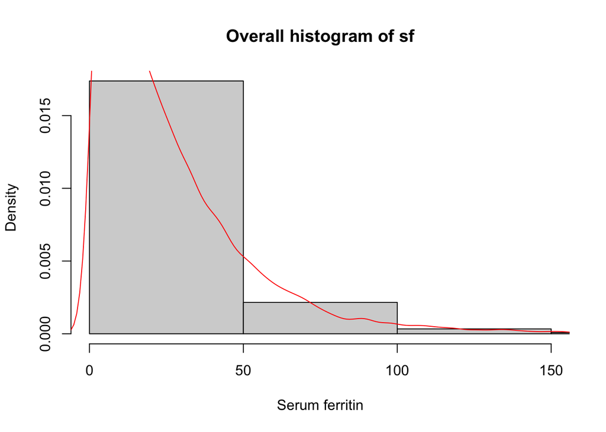

```r
# overall histogram
hist(brindanewc$sf_adj3, prob=TRUE, xlab="Serum ferritin", main="Overall histogram of sf",xlim=c(0,150))
lines(density(brindanewc$sf_adj3),col="red")
```

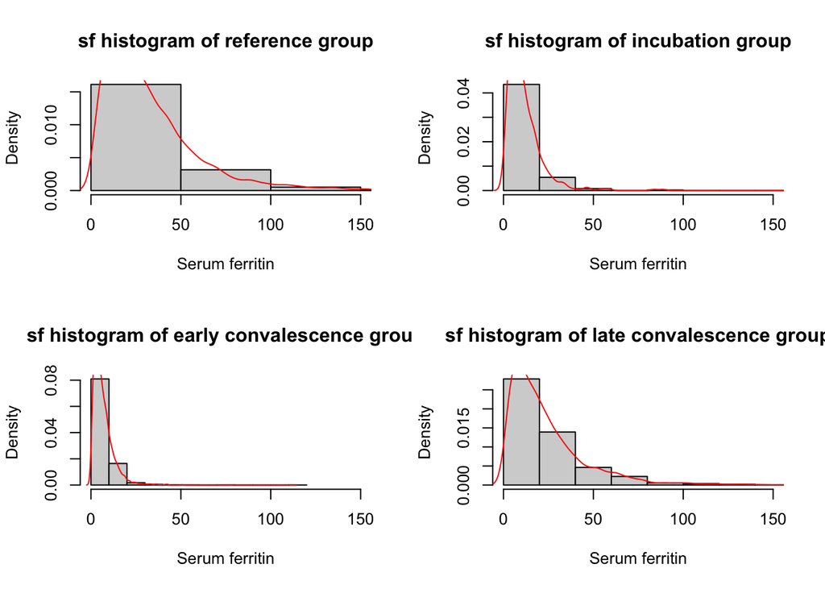

```r
# histogram by group
par(mfrow=c(2,2))
hist(brindanewc$sf_adj3[which(brindanewc$category == "Reference")], prob=TRUE, xlab="Serum ferritin", main="sf histogram of reference group",xlim=c(0,150))
lines(density(brindanewc$sf_adj3[which(brindanewc$category == "Reference")]),col="red")
hist(brindanewc$sf_adj3[which(brindanewc$category == "Incubation")], prob=TRUE, xlab="Serum ferritin", main="sf histogram of incubation group",xlim=c(0,150))
lines(density(brindanewc$sf_adj3[which(brindanewc$category == "Incubation")]),col="red")
hist(brindanewc$sf_adj3[which(brindanewc$category == "Early convalescence")], prob=TRUE, xlab="Serum ferritin", main="sf histogram of early convalescence group",xlim=c(0,150))
lines(density(brindanewc$sf_adj3[which(brindanewc$category == "Early convalescence")]),col="red")
hist(brindanewc$sf_adj3[which(brindanewc$category == "Late convalescence")], prob=TRUE, xlab="Serum ferritin", main="sf histogram of late convalescence group",xlim=c(0,150))
lines(density(brindanewc$sf_adj3[which(brindanewc$category == "Late convalescence")]),col="red")
```

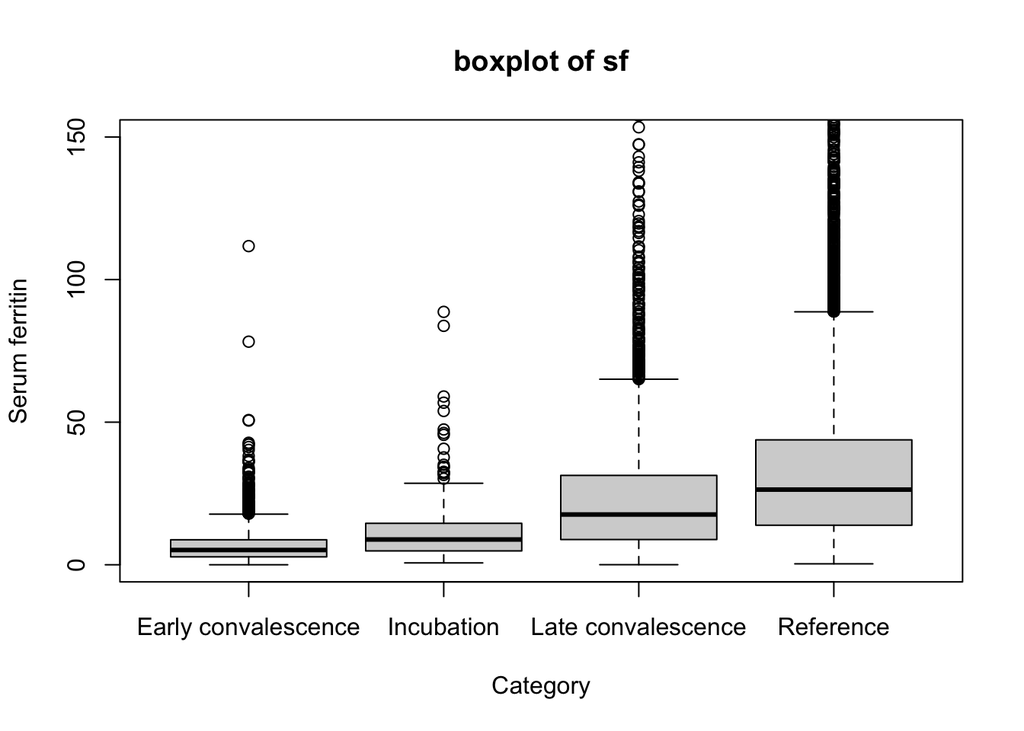

```r
# boxplot by group
par(mfrow=c(1,1))
boxplot(brindanewc$sf_adj3~brindanewc$category,main="boxplot of sf", xlab="Category",ylab="Serum ferritin",ylim=c(0,150))
```

Summary the results for method 1, 2, and 3:

```r
summary <- data.frame(Mean = c("Overall","Reference Group","Incubation","Early convalescence","Late convalescence"),
                      Method_1 = c(mean_method1,mean_method1_[[2]][4],mean_method1_[[2]][2],mean_method1_[[2]][1],mean_method1_[[2]][3]),
                      Method_2 = c(mean_method2,mean_method2_[[2]][4],mean_method2_[[2]][2],mean_method2_[[2]][1],mean_method2_[[2]][3]),
                      Method_3 = c(mean_method3,mean_method3_[[2]][4],mean_method3_[[2]][2],mean_method3_[[2]][1],mean_method3_[[2]][3]))
summary
```

```
##                  Mean Method_1 Method_2  Method_3
## 1             Overall 35.24128 53.61242 25.586447
## 2     Reference Group 34.16971 33.94011 33.940108
## 3          Incubation 34.05796 38.03285 11.619622
## 4 Early convalescence 36.44659 95.35789  6.627319
## 5  Late convalescence 36.69148 65.81737 24.204531
```

Summary plots of each category across different methods

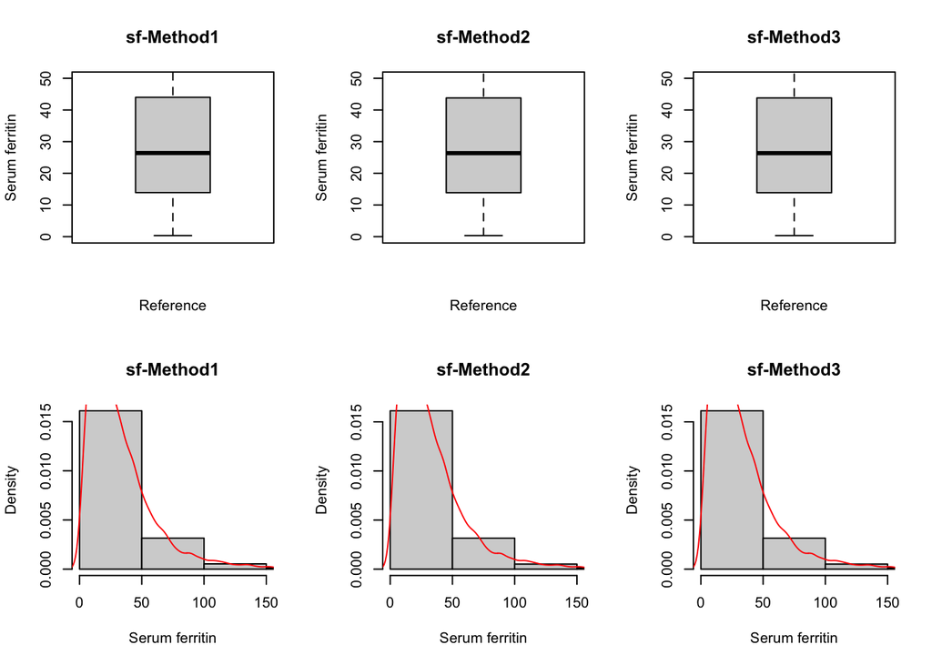

```r
par(mfrow=c(2,3))
# Reference group
boxplot(brindanewa$sf_adj1[which(brindanewa$category=="Reference")],main="sf-Method1", xlab="Reference",ylab="Serum ferritin",ylim=c(0,50))
boxplot(brindanewb$sf_adj2[which(brindanewb$category=="Reference")],main="sf-Method2", xlab="Reference",ylab="Serum ferritin",ylim=c(0,50))
boxplot(brindanewc$sf_adj3[which(brindanewc$category=="Reference")],main="sf-Method3", xlab="Reference",ylab="Serum ferritin",ylim=c(0,50))
hist(brindanewa$sf_adj1[which(brindanewa$category == "Reference")], prob=TRUE, xlab="Serum ferritin", main="sf-Method1",xlim=c(0,150))
lines(density(brindanewa$sf_adj1[which(brindanewa$category == "Reference")]),col="red")
hist(brindanewb$sf_adj2[which(brindanewb$category == "Reference")], prob=TRUE, xlab="Serum ferritin", main="sf-Method2",xlim=c(0,150))
lines(density(brindanewb$sf_adj2[which(brindanewb$category == "Reference")]),col="red")
hist(brindanewc$sf_adj3[which(brindanewc$category == "Reference")], prob=TRUE, xlab="Serum ferritin", main="sf-Method3",xlim=c(0,150))
lines(density(brindanewc$sf_adj3[which(brindanewc$category == "Reference")]),col="red")
```

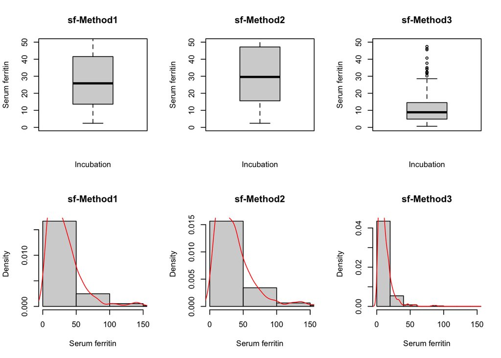

```r
# Incubation group
boxplot(brindanewa$sf_adj1[which(brindanewa$category=="Incubation")],main="sf-Method1", xlab="Incubation",ylab="Serum ferritin",ylim=c(0,50))
boxplot(brindanewb$sf_adj2[which(brindanewb$category=="Incubation")],main="sf-Method2", xlab="Incubation",ylab="Serum ferritin",ylim=c(0,50))
boxplot(brindanewc$sf_adj3[which(brindanewc$category=="Incubation")],main="sf-Method3", xlab="Incubation",ylab="Serum ferritin",ylim=c(0,50))
hist(brindanewa$sf_adj1[which(brindanewa$category == "Incubation")], prob=TRUE, xlab="Serum ferritin", main="sf-Method1",xlim=c(0,150))
lines(density(brindanewa$sf_adj1[which(brindanewa$category == "Incubation")]),col="red")
hist(brindanewb$sf_adj2[which(brindanewb$category == "Incubation")], prob=TRUE, xlab="Serum ferritin", main="sf-Method2",xlim=c(0,150))
lines(density(brindanewb$sf_adj2[which(brindanewb$category == "Incubation")]),col="red")
hist(brindanewc$sf_adj3[which(brindanewc$category == "Incubation")], prob=TRUE, xlab="Serum ferritin", main="sf-Method3",xlim=c(0,150))
lines(density(brindanewc$sf_adj3[which(brindanewc$category == "Incubation")]),col="red")
```

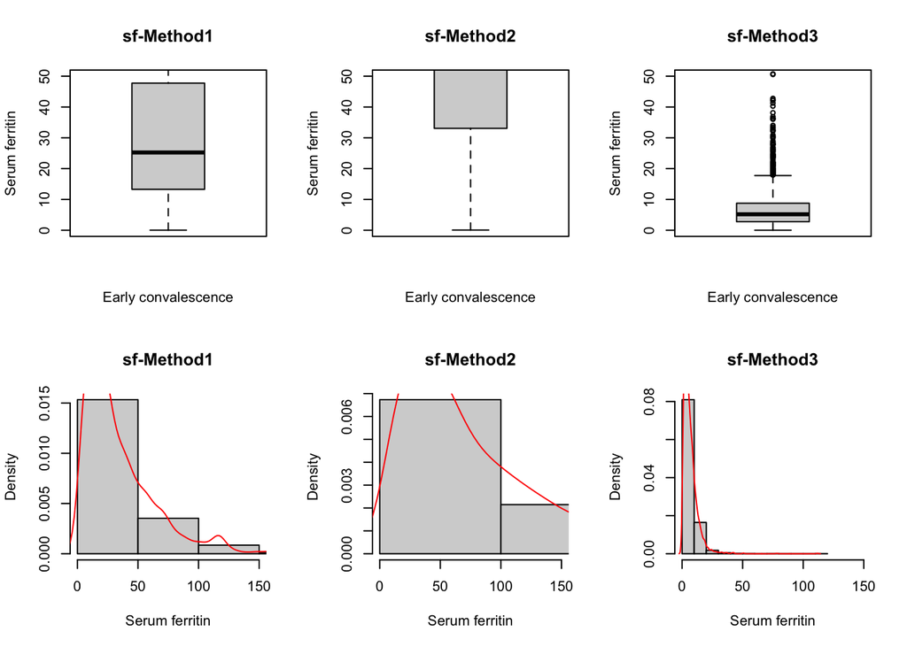

```r
# Early convalescence group
boxplot(brindanewa$sf_adj1[which(brindanewa$category=="Early convalescence")],main="sf-Method1", xlab="Early convalescence",ylab="Serum ferritin",ylim=c(0,50))
boxplot(brindanewb$sf_adj2[which(brindanewb$category=="Early convalescence")],main="sf-Method2", xlab="Early convalescence",ylab="Serum ferritin",ylim=c(0,50))
boxplot(brindanewc$sf_adj3[which(brindanewc$category=="Early convalescence")],main="sf-Method3", xlab="Early convalescence",ylab="Serum ferritin",ylim=c(0,50))
hist(brindanewa$sf_adj1[which(brindanewa$category == "Early convalescence")], prob=TRUE, xlab="Serum ferritin", main="sf-Method1",xlim=c(0,150))
lines(density(brindanewa$sf_adj1[which(brindanewa$category == "Early convalescence")]),col="red")
hist(brindanewb$sf_adj2[which(brindanewb$category == "Early convalescence")], prob=TRUE, xlab="Serum ferritin", main="sf-Method2",xlim=c(0,150))
lines(density(brindanewb$sf_adj2[which(brindanewb$category == "Early convalescence")]),col="red")
hist(brindanewc$sf_adj3[which(brindanewc$category == "Early convalescence")], prob=TRUE, xlab="Serum ferritin", main="sf-Method3",xlim=c(0,150))
lines(density(brindanewc$sf_adj3[which(brindanewc$category == "Early convalescence")]),col="red")
```

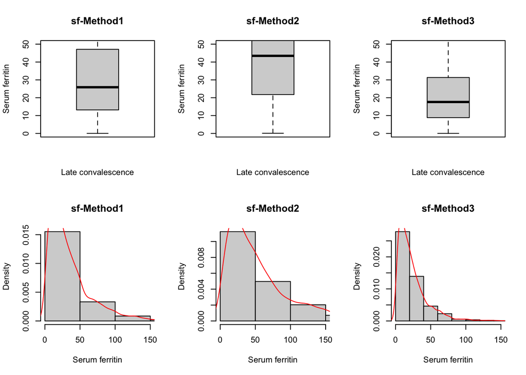

```r
# Late convalescence group
boxplot(brindanewa$sf_adj1[which(brindanewa$category=="Late convalescence")],main="sf-Method1", xlab="Late convalescence",ylab="Serum ferritin",ylim=c(0,50))
boxplot(brindanewb$sf_adj2[which(brindanewb$category=="Late convalescence")],main="sf-Method2", xlab="Late convalescence",ylab="Serum ferritin",ylim=c(0,50))
boxplot(brindanewc$sf_adj3[which(brindanewc$category=="Late convalescence")],main="sf-Method3", xlab="Late convalescence",ylab="Serum ferritin",ylim=c(0,50))
hist(brindanewa$sf_adj1[which(brindanewa$category == "Late convalescence")], prob=TRUE, xlab="Serum ferritin", main="sf-Method1",xlim=c(0,150))
lines(density(brindanewa$sf_adj1[which(brindanewa$category == "Late convalescence")]),col="red")
hist(brindanewb$sf_adj2[which(brindanewb$category == "Late convalescence")], prob=TRUE, xlab="Serum ferritin", main="sf-Method2",xlim=c(0,150))
lines(density(brindanewb$sf_adj2[which(brindanewb$category == "Late convalescence")]),col="red")
hist(brindanewc$sf_adj3[which(brindanewc$category == "Late convalescence")], prob=TRUE, xlab="Serum ferritin", main="sf-Method3",xlim=c(0,150))
lines(density(brindanewc$sf_adj3[which(brindanewc$category == "Late convalescence")]),col="red")
```

Finally, we get the serum ferritin adjusted value with three different methods. One is ratio adjustment methods, one is using regression model to eliminate the effect of reference value, and the last one is to both elimiate the effect of both reference value and category. Result shows method 2 has the similar result as original sf value for incubation group, method 2 and method 3 all lead to highly different sf adjustment value for early convalescence group, and method 3 has the similar result in sf adjustment value for late convalescence group.